# Hillenbrand_Pitch

## Pitch and Gender in the Hillenbrand database

###### Author: Dirk Van Compernolle

###### Modification History: 17/02/2023

###### Requires: pyspch>=0.7

This notebook presents a basic histogram analysis of pitch wrt. gender. Average pitch (over a single syllable word) was measured by humans in the Hillenbrand database. A clear bimodal distribution is obvious, with only minimal overlap.  
This suggests that pitch is an excellent feature to do gender recognition ... for adult speakers ! For boys and girls we see full overlap.

```python
# uncomment the pip install command to install pyspch -- it is required!
#
#!pip install git+https://github.com/compi1234/pyspch.git
#
try:
    import pyspch
except ModuleNotFoundError:
    try:
        print(
        """
        To enable this notebook on platforms as Google Colab,
        install the pyspch package and dependencies by running following code:

        !pip install git+https://github.com/compi1234/pyspch.git
        """
        )
    except ModuleNotFoundError:
        raise
```

```python
####################################################################################
### This setting is to avoid memory leaks in sklearn KMEANS on windows+MKL machines
### This must be executed before importing numpy (here or in other packages)
import os
os.environ["OMP_NUM_THREADS"] = '3'   # if you get warnings, try 1
####################################################################################
```

```python
# Importing some core Python libraries for data handling and plotting's baseline machine learning stack
#
%matplotlib inline
import sys,os
import numpy as np
import matplotlib.pyplot as plt
import matplotlib as mpl
import pandas as pd
import seaborn as sns
import pyspch.core as Spch
from pyspch.core.hillenbrand import fetch_hillenbrand, select_hillenbrand

np.set_printoptions(precision=2)
mpl.rcParams['figure.figsize'] = [8.0, 8.0]
mpl.rcParams['font.size'] = 12
mpl.rcParams['legend.fontsize'] = 'large'
mpl.rcParams['figure.titlesize'] = 'large'
```

## 1. The Hillenbrand Database

For a description of the database, see https://homes.esat.kuleuven.be/~spchlab/data/hillenbrand/README.txt  
Here we only use the **f0** data.

```python
hildata = fetch_hillenbrand(genders='all',columns=['gender','f0']).dropna()
hildata
```

| fid | gender | f0 |
| --- | --- | --- |
| m01ae | m | 174.0 |
| m02ae | m | 102.0 |
| m03ae | m | 99.0 |
| m04ae | m | 124.0 |
| m06ae | m | 115.0 |
| ... | ... | ... |
| g17uw | g | 236.0 |
| g18uw | g | 214.0 |
| g19uw | g | 243.0 |
| g20uw | g | 248.0 |
| g21uw | g | 225.0 |

1668 rows × 2 columns

## 2. Histograms of Pitch data

#### Explore

With the code cell below, you can analyze the distribution of pitch according to gender and the distinctions between young and adult speakers. Adjust your selection: e.g. ['m','w'] for men and women or ['b','g'] to visualize boys and girls.

#### Questions

- Which class pairs can you distinguish well (> 90%) on the basis of pitch alone ?
- Which class pairs are virtually non distinguishable on the basis of pitch alone ?

```python
def plot_pitch_histogram(data,selection):
    #
    long_names = {'m':'men','w':'women','b':'boys','g':'girls'}
    # gather data for the selected classes
    X1 = data.loc[data['gender']==selection[0],'f0']
    X2 = data.loc[data['gender']==selection[1],'f0']
    #
    # plot histograms of the data
    plt.figure(figsize=(8,4))
    plt.hist(X1,range=[50.,350.],bins=20,ec='b',fc=(.8,.8,1,.2))
    plt.hist(X2,range=[50.,350.],bins=20,ec='r',fc=(1,.8,.8,.2))
    plt.xlabel('Frequency (Hz)')
    plt.legend([selection[0],selection[1]])
    plt.title('Pitch Histograms for speakers in %s and %s classes' % (long_names[selection[0]], long_names[selection[1]]) );
```

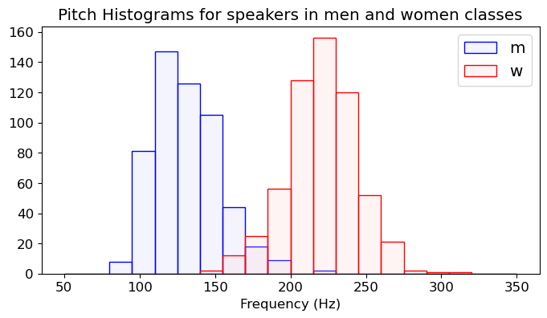

```python
# select 2 gender classes from m(en), w(omen), b(oys), g(irls)
plot_pitch_histogram( hildata,['m','w'] )
```

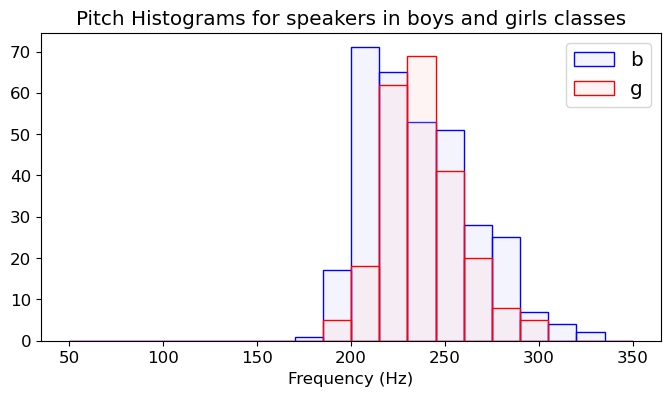

```python
plot_pitch_histogram( hildata,['b','g'] )
```

## 3. Modeling the Pitch Distributions

From observing the histograms, we see that for all subclasses the pitch values seem to be distributed quite 'normal', i.e. in the statistical sense of belonging to a normal (Gaussian) distribution. Such distributions are characterized by 2 parameters - mean and variance - which are easily estimated from the data.

```python
from sklearn.mixture import GaussianMixture


def model_data(data,genders):
    '''
    construct a normal model while selecting part of the data as specified in genders
    '''
    X1 = data.loc[data['gender']==genders[0],'f0']
    X2 = data.loc[data['gender']==genders[1],'f0']
    #
    # plot histograms of the data
    plt.figure(figsize=(8,4))
    plt.hist(X1,range=[50.,350.],bins=20,ec='b',fc=(.8,.8,1,.2))
    plt.hist(X2,range=[50.,350.],bins=20,ec='r',fc=(1,.8,.8,.2))
    plt.xlabel('Frequency (Hz)')
    plt.legend([selection[0],selection[1]])
    plt.title('Pitch Histograms for speakers in %s and %s classes' % (long_names[selection[0]], long_names[selection[1]]) );

def plot_model(data,genders):
    '''
    plot the constructed model
    '''
    data = select_hillenbrand(data,genders=genders)
    yy = data['gender'].values
    XX = data['f0'].values.reshape(-1,1)
    gmm= []
    X = []
    y = []
    for j in range(0,len(genders)):
        indx= (yy==genders[j])
        X.append( XX[indx,:])
        y.append( yy[indx])
        gmm.append( GaussianMixture(max_iter=3,random_state=1,n_components=1,init_params='kmeans'))

    fig,ax = plt.subplots(figsize=(8,4))
    f0_range = [50.,350.]
    colors = ['b','r','g','k']
    fcs = [(.8,.8,1,.2),(1,.8,.8,.2),(.8,1,.8,.2),(.8,.8,.8,.2)]
    xp  = np.linspace(f0_range[0],f0_range[1],100).reshape(-1,1)
    kws_hist = dict(histtype='stepfilled', range=f0_range, alpha=.5, bins=30, density=True)

    for j in range(0,len(genders)):
        gmm[j].fit(X[j])
        yp = gmm[j].score_samples(xp)
        ax.hist(X[j],ec=colors[j],fc=fcs[j],**kws_hist)
        ax.plot(xp,np.exp(yp),label='%s (mean=%.0f Hz) ' % (genders[j],gmm[j].means_[0]),color=colors[j])
    ax.legend(loc='upper right',fontsize='x-small')
    ax.set_xlabel('Pitch Frequency (Hz)')
    ax.grid()
```

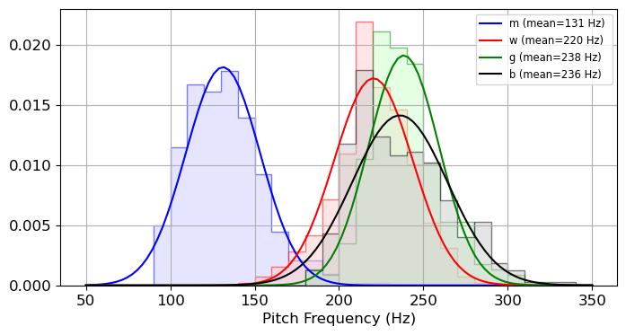

```python
plot_model(hildata,['m','w','g','b'])
```

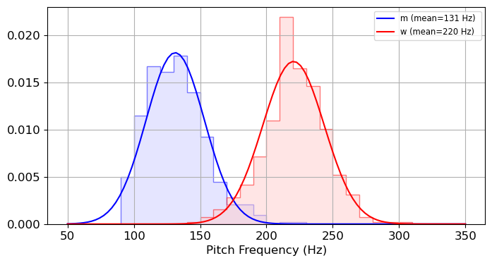

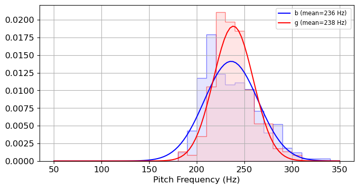

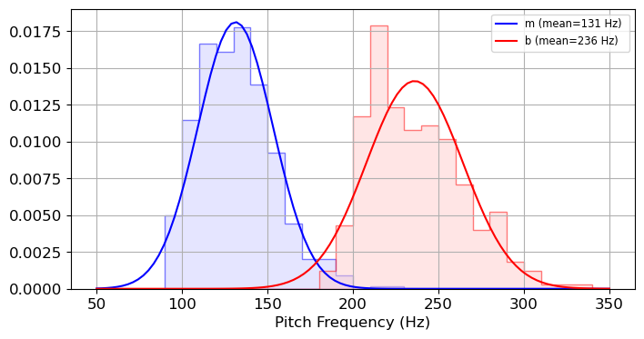

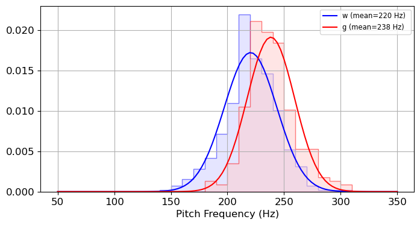

```python
for genders in [ ['m','w'], ['b','g'] , ['m','b'], ['w','g']]:
    plot_model(hildata,genders)
```